# wk10d2 homework

```r
library(tidyverse)
library(janitor)
```

# 1

> Load the housing_prices.csv data set and undertake an initial exploration of the data. You will find details on the data set on the relevant [Kaggle page](https://www.kaggle.com/datasets/camnugent/california-housing-prices)

```r
housing_prices <- read_csv("data/housing_prices.csv")
```

```r
glimpse(housing_prices)
```

```
Rows: 19,675
Columns: 10
$ longitude          <dbl> -122.23, -122.22, -122.24, -122.25, -122.25, -122.25, -122.25, -122.25, -122.2…
$ latitude           <dbl> 37.88, 37.86, 37.85, 37.85, 37.85, 37.85, 37.84, 37.84, 37.84, 37.84, 37.85, 3…
$ housing_median_age <dbl> 41, 21, 52, 52, 52, 52, 52, 52, 42, 52, 52, 52, 52, 52, 52, 50, 52, 52, 50, 52…
$ total_rooms        <dbl> 880, 7099, 1467, 1274, 1627, 919, 2535, 3104, 2555, 3549, 2202, 3503, 2491, 69…
$ total_bedrooms     <dbl> 129, 1106, 190, 235, 280, 213, 489, 687, 665, 707, 434, 752, 474, 191, 626, 28…
$ population         <dbl> 322, 2401, 496, 558, 565, 413, 1094, 1157, 1206, 1551, 910, 1504, 1098, 345, 1…
$ households         <dbl> 126, 1138, 177, 219, 259, 193, 514, 647, 595, 714, 402, 734, 468, 174, 620, 26…
$ median_income      <dbl> 8.3252, 8.3014, 7.2574, 5.6431, 3.8462, 4.0368, 3.6591, 3.1200, 2.0804, 3.6912…
$ median_house_value <dbl> 452600, 358500, 352100, 341300, 342200, 269700, 299200, 241400, 226700, 261100…
$ ocean_proximity    <chr> "NEAR BAY", "NEAR BAY", "NEAR BAY", "NEAR BAY", "NEAR BAY", "NEAR BAY", "NEAR …
```

Dataset about areas - population, households, features of these. One character column (ocean_proximity), rest are numeric: location, local population size and number of households, number of rooms and bedrooms in the population’s households, median age (of the population from 1990 census), median income, median house value.

```r
housing_prices %>%
  summarise(across(everything(),
                   ~sum(is.na(.x))))
```

| longitude | latitude | housing_median_age | total_rooms | total_bedrooms | population | households | median_income | median_house_value | ocean_proximity |
| --- | --- | --- | --- | --- | --- | --- | --- | --- | --- |
| 0 | 0 | 0 | 0 | 200 | 0 | 0 | 0 | 0 | 0 |

Only var with missing values is total_bedrooms, 200 NAs out of the 19,675 observations. Tbc how to deal with these, if at all.

# 2

> We expect the total_rooms of houses to be strongly correlated with total_bedrooms. Use ggpairs() to investigate correlations between these two variables.

It’s overkill to look at all the vars, so just look at the two of interest:

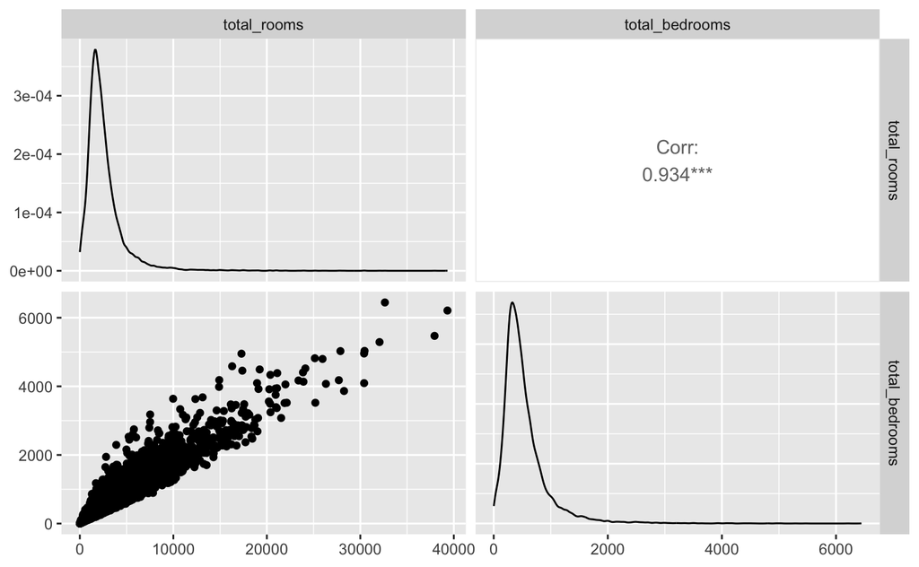

```r
housing_prices %>%
  select(total_rooms, total_bedrooms) %>%
  GGally::ggpairs()
```

They look strongly positively correlated, and corr = 0.934 so that indicates a very strong positive correlation. (And *** indicate this is statistically significant, i.e. we can reject the null hypothesis that total_bedrooms does not affect total_rooms; it is very unlikely this data is from a world where the null hypothesis is true.)

# 3

> drop total_bedrooms from the dataset, and use only total_rooms going forward

Because these variables are related, we should only use one of these in our model.

| longitude | latitude | housing_median_age | total_rooms | population | households | median_income | median_house_value | ocean_proximity |
| --- | --- | --- | --- | --- | --- | --- | --- | --- |
| -122.23 | 37.88 | 41 | 880 | 322 | 126 | 8.3252 | 452600 | NEAR BAY |
| -122.22 | 37.86 | 21 | 7099 | 2401 | 1138 | 8.3014 | 358500 | NEAR BAY |
| -122.24 | 37.85 | 52 | 1467 | 496 | 177 | 7.2574 | 352100 | NEAR BAY |
| -122.25 | 37.85 | 52 | 1274 | 558 | 219 | 5.6431 | 341300 | NEAR BAY |
| -122.25 | 37.85 | 52 | 1627 | 565 | 259 | 3.8462 | 342200 | NEAR BAY |
| -122.25 | 37.85 | 52 | 919 | 413 | 193 | 4.0368 | 269700 | NEAR BAY |
| -122.25 | 37.84 | 52 | 2535 | 1094 | 514 | 3.6591 | 299200 | NEAR BAY |
| -122.25 | 37.84 | 52 | 3104 | 1157 | 647 | 3.1200 | 241400 | NEAR BAY |
| -122.26 | 37.84 | 42 | 2555 | 1206 | 595 | 2.0804 | 226700 | NEAR BAY |
| -122.25 | 37.84 | 52 | 3549 | 1551 | 714 | 3.6912 | 261100 | NEAR BAY |

[output cut: 990 more lines]

# 4

> We are interested in developing a regression model for the median_house_value of a house in terms of the possible predictor variables in the dataset. i. Use ggpairs() to investigate correlations between median_house_value and the predictors (this may take a while to run, don’t worry, make coffee or something).

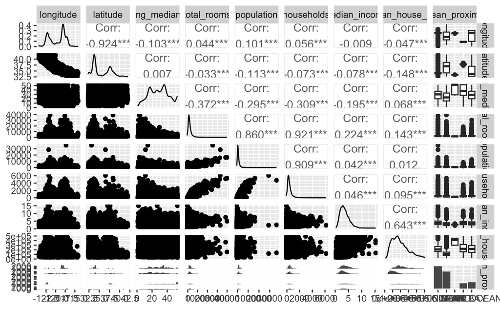

From these, it looks like there are otherexplanatory variables that are strongly related:

- population, household and total_rooms are all correlated - they could be combined to create a derived variable as some kind of indicator of housing supply/demand, e.g. households * total_rooms / population (where > 1 is plenty of supply, < 1 is not enough supply, so some demand pressure)
- long and lat are two parts to a location, and are strongly related - they should be combined to indicate individual locations (or areas) in California (where this data is about)

Taking these into account, and looking at the magnitude of the correlation coefficients that are significant (*s), I would consider including the following in a model, in order of steps:

1. income
2. location (lat, long)
3. demand (something derived from pop, household, rooms)
4. age
> 2. Perform further ggplot visualisations of any significant correlations you find.

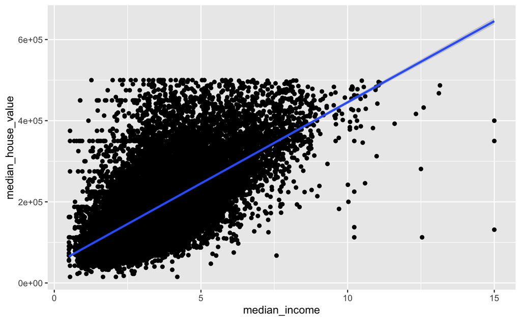

```r
housing_prices %>%
  ggplot(aes(x = median_income, y = median_house_value)) +
  geom_point(fill = "grey60") +
  geom_smooth(method = lm, se = TRUE)
```